# MA331-Coursework

Text analytics of the TED talks by Marco Tempest and Michael Shermer

2110390-Adekemi-Kadri

**INTRODUCTION**

The following report is based on word frequency comparisons and sentiment analysis of five (5) transcripts of TED talks of Marco Tempest and Michael Shermer. Sentiment Analysis is a process of extracting opinions that have different scores like positive, negative or neutral.It is a type of classification where data is classified into different classes like positive or negative or happy, sad, angry, etc.

**About Marco Tempest & Michael Shermer; and their Ted Talks to be Analysed**

On the other hand, Michael Shermer in his ted talks debunks myths, superstitions and urban legends with explanations on why people believe them. In this report the following talks were analysed for Michael Shermer;

1. Why people believe weird things and The pattern behind self-deception (February 2006): In this talk, Michael described how people see the Virgin Mary on a cheese sandwich or hear demonic lyrics in stairway to heaven. He used video and music to reveal how we convince ourselved to believe and ignore the facts.
2. The pattern behind self-deception (February 2010): According to Michael in this talk, the human tendency to believe strange things, from alien abductions to dowsing rods has to do with the brain’s most fundamental hard-wired survival techniques.

```
## # A tibble: 5 x 3
##   speaker         headline                                   Year_of_Talk
##   <chr>           <chr>                                      <chr>
## 1 Michael Shermer Why people believe weird things            Feb 2006
## 2 Michael Shermer The pattern behind self-deception          Feb 2010
## 3 Marco Tempest   A magical tale (with augmented reality)    March 2012
## 4 Marco Tempest   The electric rise and fall of Nikola Tesla March 2012
## 5 Marco Tempest   And for my next trick, a robot             March 2012
```

*Table 1: Ted Talk Data*

**METHODOLOGY**

Two function of the sentiment score methods and emotion classification will be used for the sentiment analysis. Before the analysis, the transcript would be tidy using the tidyverse library and stop words would be removed, stopwords are the most commonly occurring words in a language and have very little value in terms of gaining useful information. Examples of stopwords in English are “the, is, at, on”.

**i. Sentiment score:** Sentiments can be classified as positive, neutral or negative. To better express the strength of positive or negative sentiment, they can also be expressed on a numeric scale. For this analysis, we will be using the “bing” and “nrc” function for the sentiment analysis. Statistics summary of the sentiment derived from the “bing” function will be used for the sentiment score.

**ii. Emotion Classification:** Emotion classification is built on the NRC Word-Emotion Association Lexicon (aka EmoLex). “The NRC Emotion Lexicon is a list of English words and their associations with eight basic emotions (anger, fear, anticipation, trust, surprise, sadness, joy, and disgust) and two sentiments (negative and positive). In this analysis, log odds ration on”nrc” function will be used to get the emotion classification for both speakers.

**Log odds ratio** Logging the odds ratio provides a measure that is symmetric when comparing the usage of word across the ted talks.Log odds ratio of words is given as:
$$log( O^i_{w}/ O^j_{w})$$
where i and j represent each ted talk speakers.

**Visualisation**

Word cloud and geom_bar will be used to view each speaker’s words and the ggrepel visualisation function will be used to compare them. A word cloud is one of the most popular ways to visualize and analyze qualitative data. It’s an image composed of keywords found within a body of text, where the size of each word indicates its frequency in that body of text.

**RESULTS**

**Analysis of each Ted Talk speaker**

Marco Tempest word analysis

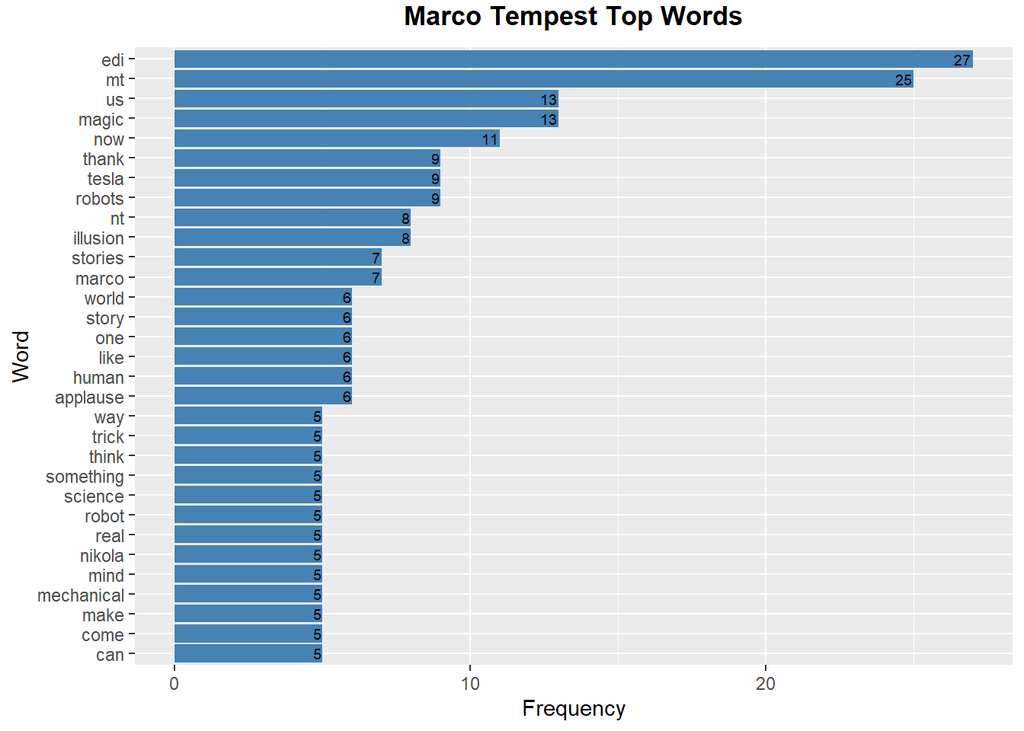

*Figure 1: Marco Tempest Top Words*

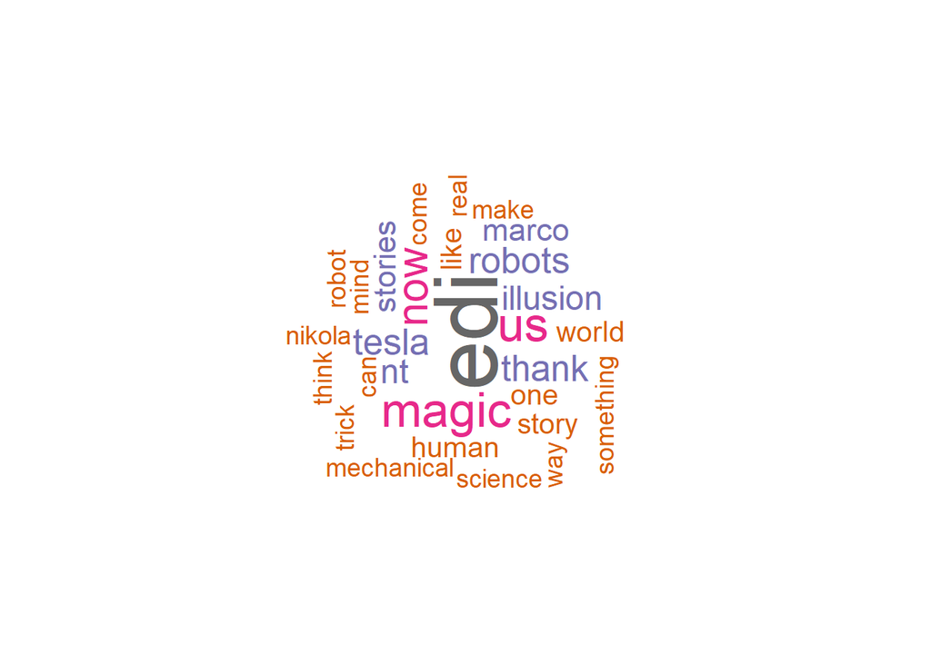

*Fig 2: Marco Tempest Word Cloud*

**Michael Shermer Top Words**

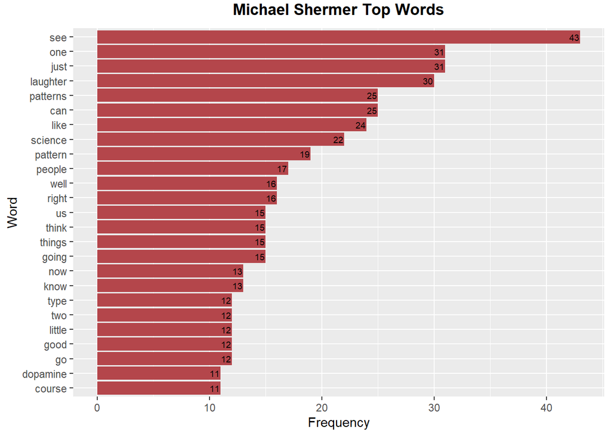

*Fig 3: Michael Schermer Top Words*

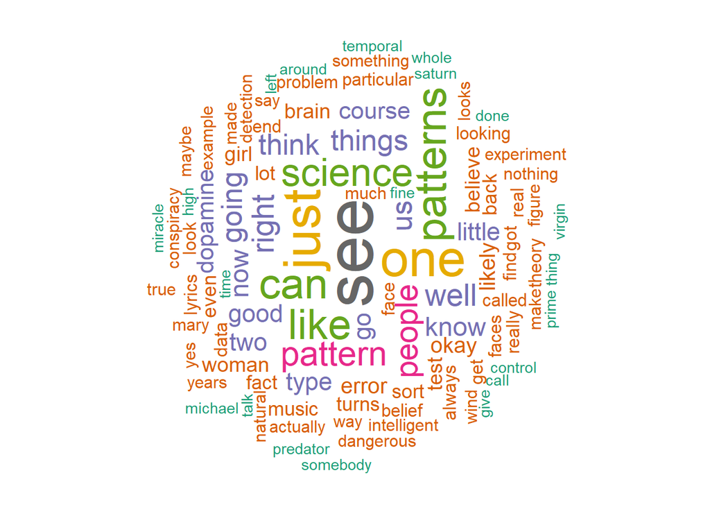

*Fig 4: Michael Shermer Top Words*

**Word Comparison of Both Speakers**

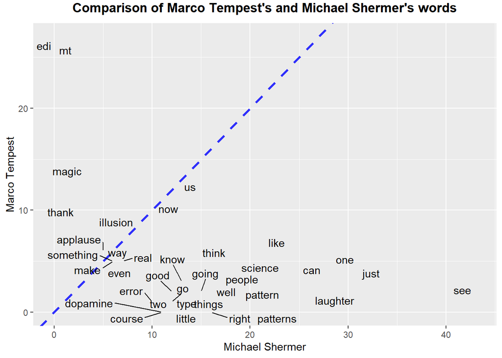

*Fig 5: Word Comparison of Marco Tempest & Michael Shermer*

Fig 5 is a plot of the Macro Tempest words vs. those of Michael Shermer. Marco’s words appear on the left side whereas Michael’s appear on the right. The words on the line represent the words both speakers used, words like “something”,“make”, “way” are the common words that are used by both speakers.

**SENTIMENT ANALYSIS**

**a. Sentiment Score (‘bing’ function)**

```
## # A tibble: 260 x 4
##    speaker       word        sentiment     n
##    <chr>         <chr>       <chr>     <int>
##  1 Marco Tempest achievement positive      1
##  2 Marco Tempest advantage   positive      1
##  3 Marco Tempest amazement   positive      1
##  4 Marco Tempest bad         negative      1
##  5 Marco Tempest beautiful   positive      1
##  6 Marco Tempest best        positive      1
##  7 Marco Tempest cheer       positive      1
##  8 Marco Tempest clever      positive      1
##  9 Marco Tempest comfortable positive      1
## 10 Marco Tempest cry         negative      1
## # ... with 250 more rows
```

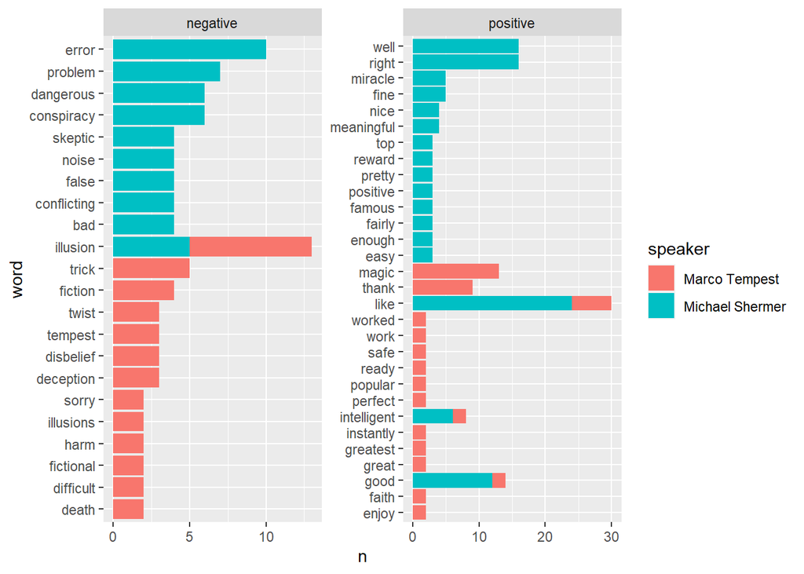

*Fig 6: Sentiment Score Analysis*

```
## # A tibble: 4 x 3
##   sentiment speaker             n
##   <chr>     <chr>           <int>
## 1 negative  Marco Tempest      77
## 2 negative  Michael Shermer   155
## 3 positive  Marco Tempest     101
## 4 positive  Michael Shermer   180
```

*Table 3: Positive and Negative Words For Each Speaker(Sentiment Score)*

**b.Emotional Classificaton (nrc function)**

The table below shows the sentiment of each speaker using emotional classification and the log odds ratio of the sentiments.

```
## # A tibble: 10 x 5
##    sentiment    `Marco Tempest` `Michael Shermer`    OR  log_OR
##    <fct>                  <int>             <int> <dbl>   <dbl>
##  1 anger                     22                33 1.29   0.255
##  2 anticipation              66               124 1.02   0.0242
##  3 disgust                    9                30 0.569 -0.564
##  4 fear                      36                74 0.929 -0.0733
##  5 joy                       71               115 1.21   0.192
##  6 negative                  62               137 0.853 -0.159
##  7 positive                 145               245 1.18   0.167
##  8 sadness                   30                70 0.813 -0.207
##  9 surprise                  58               103 1.09   0.0862
## 10 trust                     72               165 0.814 -0.206
```

*Table 4: Sentiment and Log odds ratio of Marco Tempest & Michael Shermer*

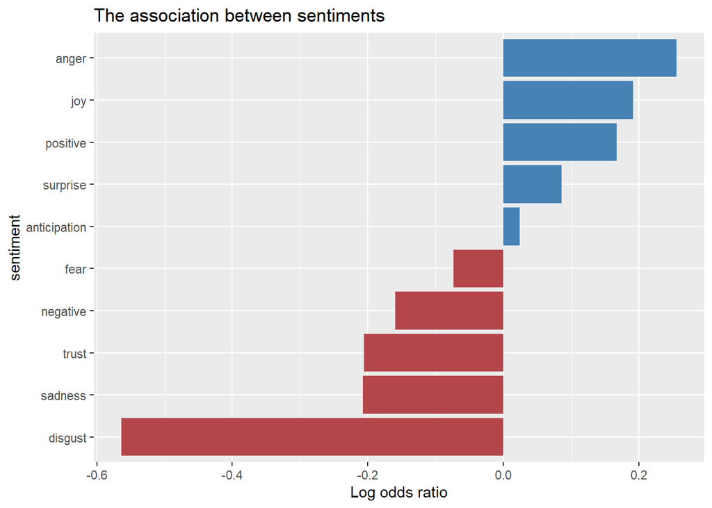

*Fig 7: Emotional Classification Analysis*

**DISCUSSION**

Sentiment analysis provides a way to understand the attitudes and opinions expressed in words. In this report, we explored how to approach sentiment analysis using tidy data principles; when text data is in a tidy data structure, sentiment analysis can be implemented as an inner join.Using two methods of sentiment analysis on the TED talk data, it was observed that Michael Shermer used many negative words during shows compared Marco Tempest.